# MVCAA Tutorial 1: Exploring PurpleAir Data

Jonathan Callahan

2026-05-06

## Introductionget

This tutorial demonstrates how to create *pas*, *pat* and *monitor* objects for PurpleAir sensors in a particular community. Target audiences include grad students, researchers, air quality professionals and any member of the public concerned about air quality and comfortable working with **R** and RStudio.

## Goal

Our goal in this tutorial is to create *pas*, *pat* and *monitor* objects (data structures) for the Methow Valley – a community in north-central Washington state. [Clean Air Methow](https://www.cleanairmethow.org) operates as a project of the [Methow Valley Citizens Council](http://mvcitizens.org) and began deploying PurpleAir Sensors in 2018:

> In the summer of 2018, Clean Air Methow launched the Clean Air Ambassador Program, an exciting citizen science project, and one of the largest, rural networks of low-cost sensors in the world!

This tutorial will demonstrate how to access and work with data from this collection of sensors.

## Data Structures

*pas* objects in the **AirSensor** package contain per-instrument metadata for a collection of PurpleAir sensors. This will include both “spatial metadata” like longitude, latitude, timezone, *etc.* as well as each instrument’s `sensor_index`, allowing us to request timeseries data from the PurpleAir API.

*pat* objects in the **AirSensor** package contain time-invariant spatial metadata for a single sensor as well as the time-dependent measurements made by that sensor.

*monitor* objects in the **AirMonitor** package contain time-invariant spatial metadata for multiple sensors as well as the time-dependent PM2.5 measurements made by those sensors.

## Preparing the Environment

Before we start working with PurpleAir data we need to get a few things set up:

```r
# AirSensor2 package
library(AirSensor2)
# Working from the git repo, your directory should end with "AirSensor2"
cat(getwd())
```

```
## /Users/jonathancallahan/Projects/MazamaScience/AirSensor2
```

```r
# Set user's PurpleAir_API_READ_KEY
library(dotenv)
dotenv::load_dot_env()

PurpleAir_API_READ_KEY <- Sys.getenv("PurpleAir_API_READ_KEY")

# Check that the key works
PurpleAir_checkAPIKey(PurpleAir_API_READ_KEY)
```

```
## $api_version
## [1] "V1.2.0-1.1.45"
##
## $time_stamp
## [1] "2026-05-06 17:17:32 UTC"
##
## $api_key_type
## [1] "READ"
```

```r
# Set this key once for all pas_/pat_ functions
setAPIKey("PurpleAir-read", PurpleAir_API_READ_KEY)

# Initialize previously installed spatial datasets
initializeMazamaSpatialUtils()
```

## Create a PurpleAirSynoptic (pas) object

To find the sensors we wish to investigate, we must first create a *pas* object with metadata for all PurpleAir senors in our target area. The Methow Valley valley is located entirely within Okanogan County, WA, so we can create an Okanogan-only *pas* object as our starting point.

```r
# Create a new 'pas' object for Okanogan county
okanogan_pas <-
  pas_createNew(
    countryCodes = "US",
    stateCodes = "WA",
    counties = c("Okanogan"),
    lookbackDays = 0,           # all historical sensors
    location_type = 0           # outdoor sensors only
  )

# Interactive map
okanogan_pas %>% pas_leaflet()
```

[interactive chart not shown]

### Explore available sensors

Clicking on some of the sensors in the Methow Valley, it quickly becomes apparent that many of those sensors have a label that associates them with the “Clean Air Ambassador” program. Unfortunately, the naming is not consistent.

A quick review of `sort(okanogan_pas$locationName)` reveals:

- “Clean Air Ambassador @…”
- “MV Ambassador @…”
- “MV Ambassadors@…”
- “MV Clean Air Abassador @…”
- “MV Clean Air Ambassador @…”
- “MV Clean Air Ambassador-…”
- “MVCC Ambassador @…”
- “MVCC Ambassador@…”

Clearly, some effort was made to systematize the naming even if it wasn’t entirely successful. Nevertheless, we can filter for all location names that begin with “MV” or “Clean Air” to create a MVCAA-only *pas* object

```r
mvcaa_pas <-
  okanogan_pas %>%
  pas_filter(stringr::str_detect(locationName, "^MV|^Clean Air"))

# Interactive map
mvcaa_pas %>% pas_leaflet()
```

[interactive chart not shown]

### Sensor Lifespans

Along with **where** sensors are located, it’s important to know **when** they collected data. (Low-cost sensors don’t last forever.) The `pas_lifespanPlot()` helps with this as seen in the following two examples:

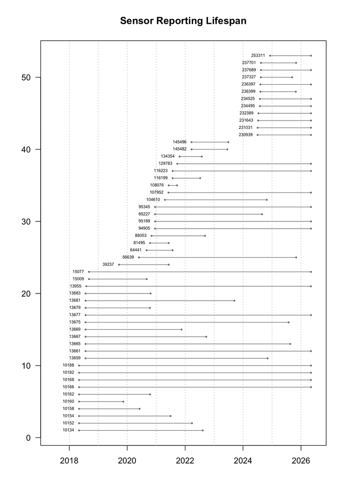

```r
# Quick look at sensor lifespans
mvcaa_pas %>%
  pas_lifespanPlot(showSensor = TRUE, moreSpace = 0.1)
```

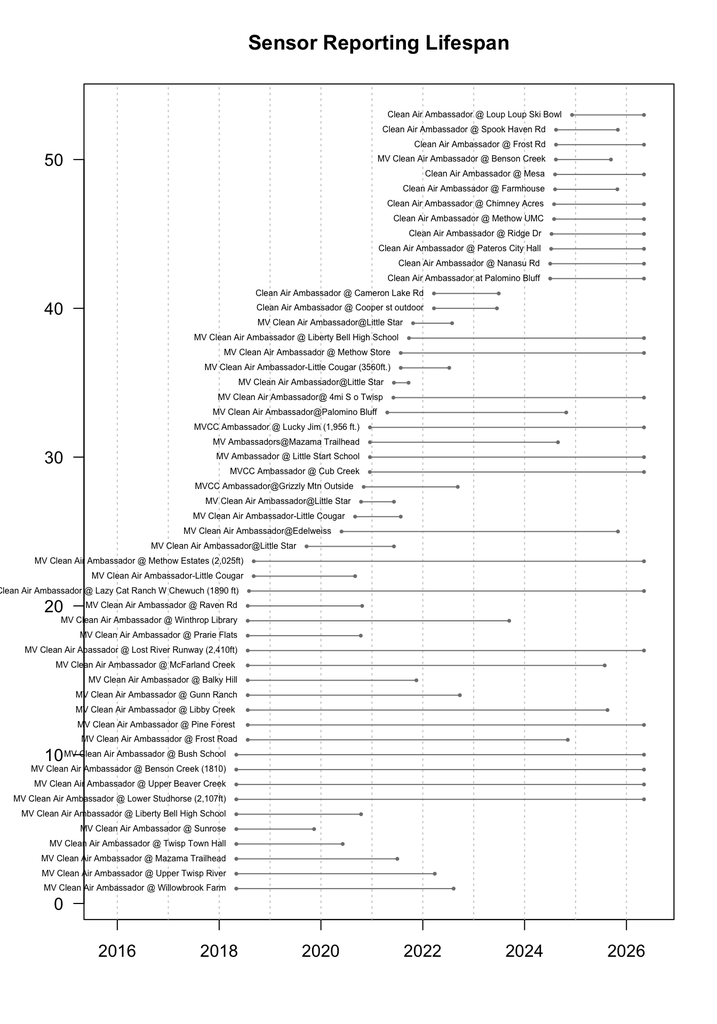

```r
# Human readable names
mvcaa_pas %>%
  pas_lifespanPlot(
    showSensor = TRUE,
    moreSpace = 0.3,
    sensorIdentifier = "locationName"
    )
```

## Create a PurpleAirTimeseries (pat) object

A *pat* object contains time series data for a specific sensor. The `pat_create()` function downloads all data records for a sensor – “raw data” typically measured every 2 minutes. A similar function, `pat_createHourly()`, downloads *hourly aggregated* data as provided by the PurpleAir API.

### Raw Data

The `pat_create()` function has a `fields` argument that lets you specify which data fields should be included in the result. But default, it uses all those defined in `PurpleAir_PAT_QC_FIELDS`:

```
##  [1] "rssi"        "uptime"      "pa_latency"  "memory"      "humidity"
##  [6] "temperature" "pressure"    "pm2.5_atm"   "pm2.5_atm_a" "pm2.5_atm_b"
```

Clicking on the leaflet map above, we identify the `sensor_index` for the sensor at “Little Start School” as `"95189"`. (Zoom in on Winthrop to see it.) From the lifespan plot, we can see that this monitor was first deployed at the end of 2020 and is still producing data.

The following chunk of code creates a raw *pat* object for this sensor:

```r
# Create raw pat object
pat <-
  pat_create(
    api_key = PurpleAir_API_READ_KEY,
    pas = mvcaa_pas,
    sensor_index = "95189",
    startdate = "2025-09-01",
    enddate = "2025-09-08",
    timezone = "UTC",
    verbose = TRUE
  )

# Pull out data
tbl <- pat$data

# Review parameters
names(tbl)
```

```
##  [1] "datetime"    "rssi"        "uptime"      "pa_latency"  "memory"
##  [6] "humidity"    "temperature" "pressure"    "pm2.5_atm"   "pm2.5_atm_a"
## [11] "pm2.5_atm_b"
```

We can now use the standard behavior of the base `plot()` function to review all parameters and look for any interesting correlations among them.

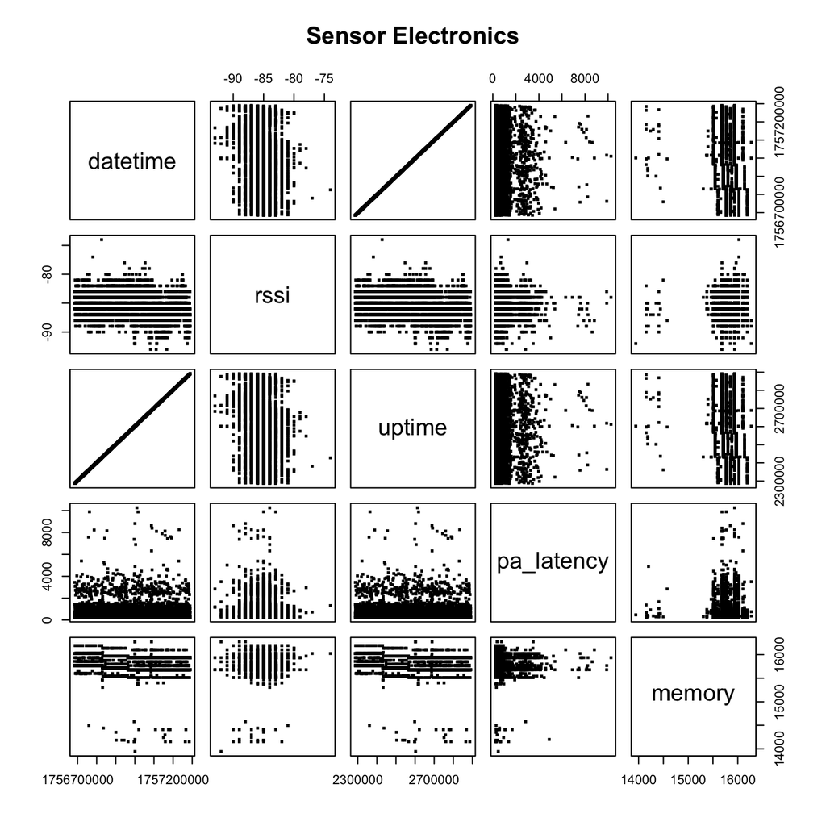

```r
# NOTE:  Using "pch = 15" greatly improves the speed of drawing

# Sensor Electronics
plot(tbl[,c(1,2:5)], pch = 15, cex = 0.5, main = "Sensor Electronics")
```

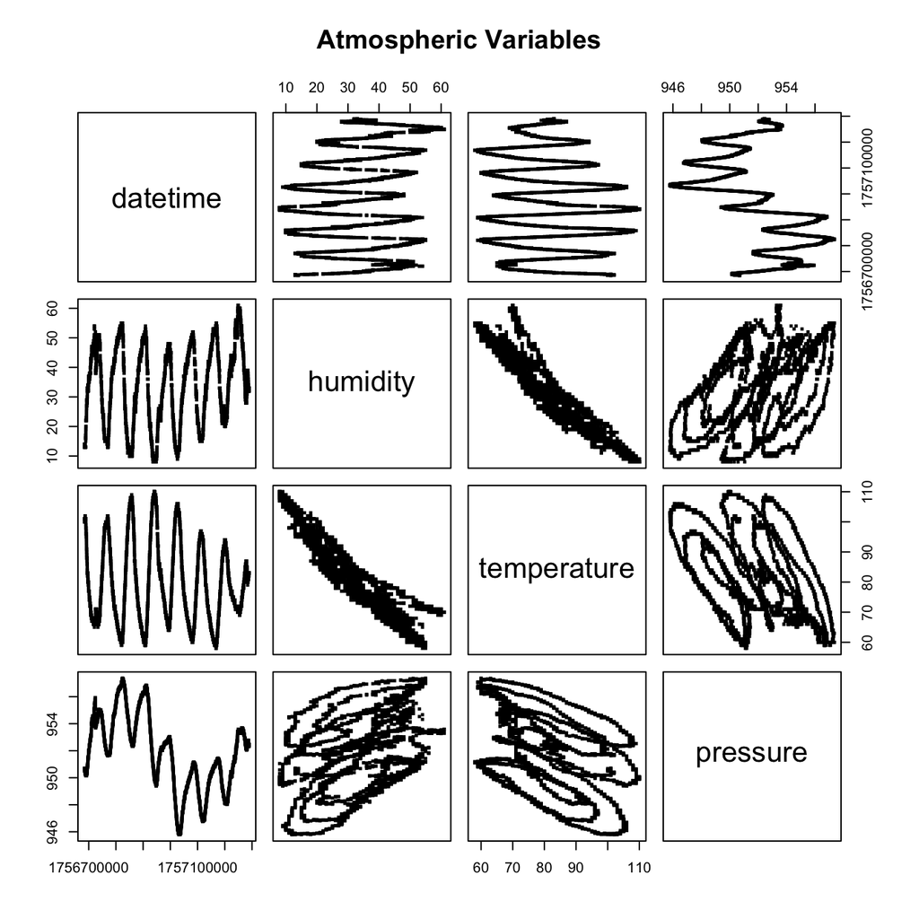

```r
# Atmospheric Variables
plot(tbl[,c(1,6:8)], pch = 15, cex = 0.5, main = "Atmospheric Variables")
```

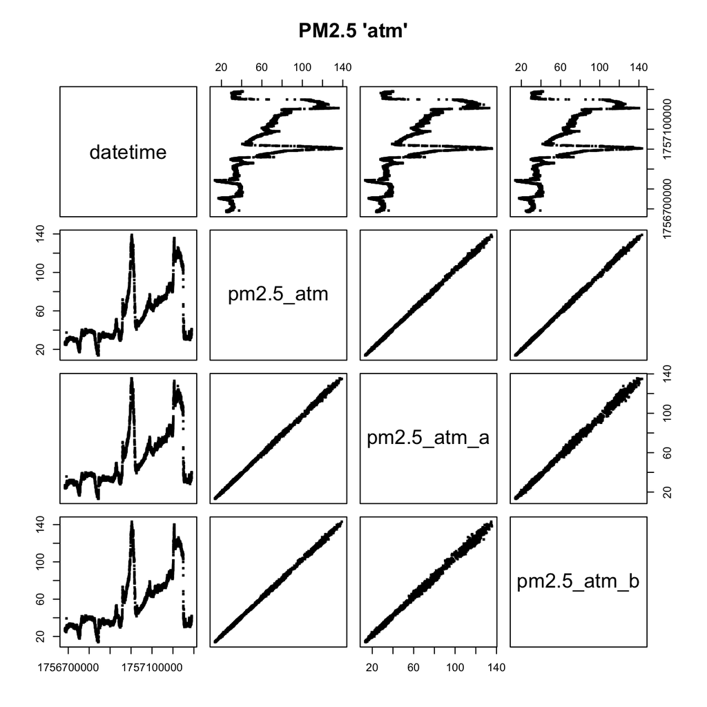

```r
# PM2.5 "atm"
plot(tbl[,c(1,9:11)], pch = 15, cex = 0.5, main = "PM2.5 'atm'")
```

*While useful for engineering-level analysis, it is important to note that high resolution, raw data can consume a lot of points interacting with the PurpleAir API. Creation of hourly data is much more frugal, utilizing the API’s ability to aggregate data.*

## Create a ‘monitor’ object

For use cases involving comparison with regulatory monitors, calculating daily averages or informing the public, it is imperative to use hourly aggregated data that has had a correction equation applied. *(PurpleAir sensors tend to report pm2.5 values that are higher than those reported by EPA regulatory monitors.)*

The `pat_createHourly()` function only downloads those parameters typically used in QC and correction functions. A `correction_FUN` is applied to the hourly *pat* object and returns corrected PM2.5 values. By default, an EPA vetted correction function is applied that brings PurpleAir values in line with EPA data even in the smoky conditions seen with wildfire smoke. (See the documentation for `pat_applyCorrection()` for details.)

```r
# "Mazama Trailhead" during the Cedar Creek and Cub Creek fires of 2021
trailhead_hourly <-
  pat_createHourly(
    api_key = PurpleAir_API_READ_KEY,
    pas = mvcaa_pas,
    sensor_index = "95227",           # Mazama Trailhead
    startdate = "2021-07-15",
    enddate = "2021-08-01",
    timezone = "America/Los_Angeles", # timestamps interpreted in this time zone
    verbose = TRUE
  )

# This object has hourly data in the 'data' dataframe
head(trailhead_hourly$data)
```

```
## # A tibble: 6 × 6
##   datetime            humidity temperature pm2.5_atm pm2.5_atm_a pm2.5_atm_b
##   <dttm>                 <dbl>       <dbl>     <dbl>       <dbl>       <dbl>
## 1 2021-07-15 07:00:00       23          78      16          15.9        16.2
## 2 2021-07-15 08:00:00       24          77      12.5        12.6        12.4
## 3 2021-07-15 09:00:00       26          75       8.8         8.8         8.8
## 4 2021-07-15 10:00:00       28          74       6.6         6.7         6.5
## 5 2021-07-15 11:00:00       28          74       5.6         5.6         5.6
## 6 2021-07-15 12:00:00       30          73       5.2         5.2         5.1
```

The `pat_toMonitor()` function returns a *monitor* object ready to use with the AirMonitor and AirMonitorPlots packages.

```r
trailhead_monitor <-
  trailhead_hourly %>%
  pat_toMonitor()

# Now we have corrected pm2.5 with a 'deviceDeploymentID' column header
head(trailhead_monitor$data)
```

```
## # A tibble: 6 × 2
##   datetime            c2dkknhd2_pa.95227
##   <dttm>                           <dbl>
## 1 2021-07-15 07:00:00              12.2
## 2 2021-07-15 08:00:00              10.2
## 3 2021-07-15 09:00:00               8.12
## 4 2021-07-15 10:00:00               6.79
## 5 2021-07-15 11:00:00               6.27
## 6 2021-07-15 12:00:00               5.89
```

We can now use functions from the **AirMonitor** and **AirMonitorPlots** packages to manipulate and visualize this data.

*NOTE: Values are in units of µg/m³ not AQI.*

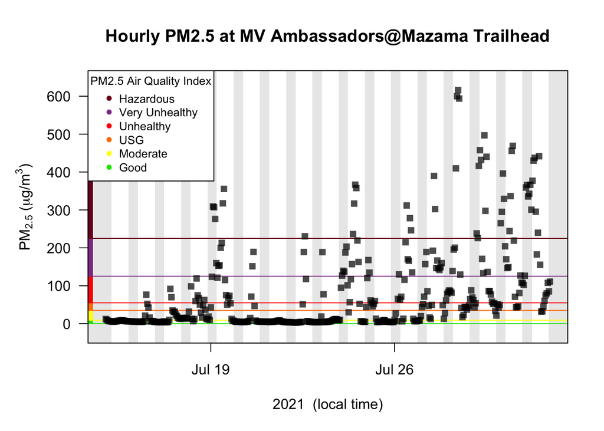

```r
# Create a basic timeseries plot
AirMonitor::monitor_timeseriesPlot(
  trailhead_monitor,
  shadedNight = TRUE,
  addAQI = TRUE
)
AirMonitor::addAQILegend("topleft", cex = 0.8, bg = "white")
```

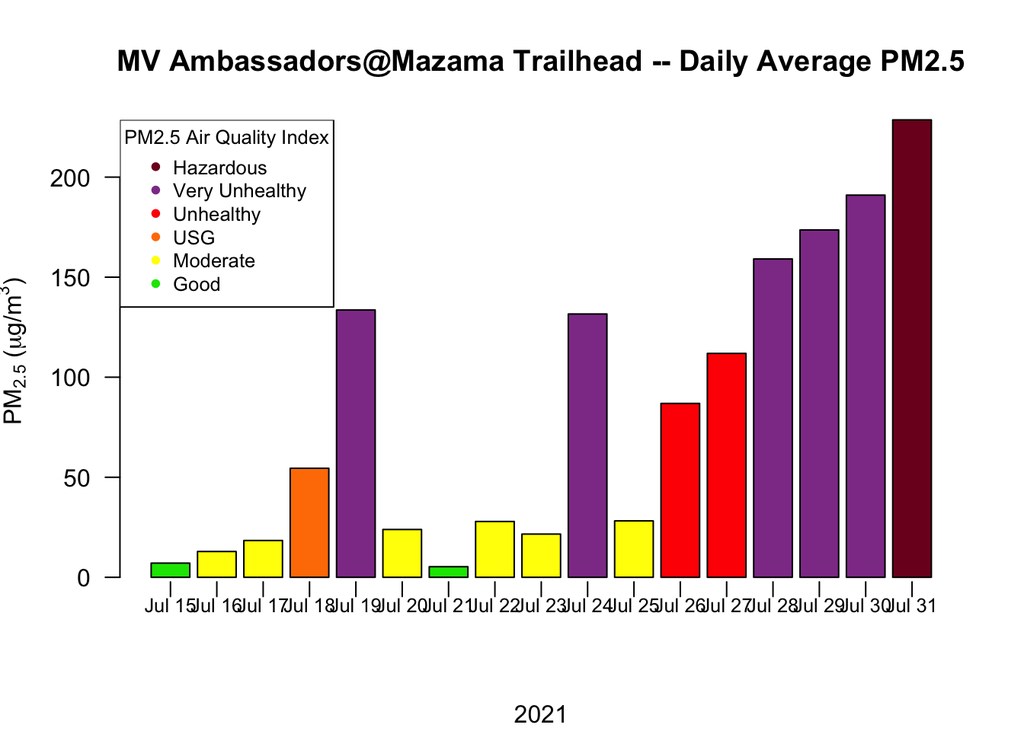

```r
# Create a daily barplot
trailhead_monitor %>%
  AirMonitor::monitor_dailyBarplot()
AirMonitor::addAQILegend("topleft", cex = 0.8, bg = "white")
```

```r
# Extract regulatory daily averages using "Local Standard Time"
trailhead_monitor %>%
  AirMonitor::monitor_dailyStatistic(
    FUN = mean,
    minHours = 18,
    dayBoundary = "LST"
  ) %>%
  AirMonitor::monitor_getData() %>%
  dplyr::mutate(datetime = as.Date(datetime)) %>%
  dplyr::rename_with(~ c("date", "pm25_mean")) %>%
  print()
```

```
## # A tibble: 18 × 2
##    date       pm25_mean
##    <date>         <dbl>
##  1 2021-07-14     NA
##  2 2021-07-15      6.86
##  3 2021-07-16     12.8
##  4 2021-07-17     18.8
##  5 2021-07-18     55.7
##  6 2021-07-19    132.
##  7 2021-07-20     23.9
##  8 2021-07-21      5.22
##  9 2021-07-22     27.9
## 10 2021-07-23     26.7
## 11 2021-07-24    133.
## 12 2021-07-25     21.6
## 13 2021-07-26     87.3
## 14 2021-07-27    114.
## 15 2021-07-28    158.
## 16 2021-07-29    173.
## 17 2021-07-30    204.
## 18 2021-07-31    223.
```

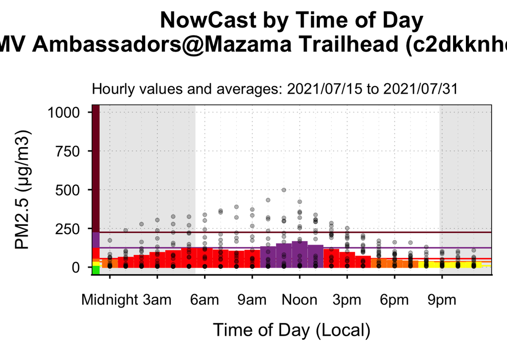

```r
# Use AirMonitorPlots to create a "diurnal" plot
trailhead_monitor %>%
  AirMonitorPlots::monitor_ggDailyByHour_archival()
```

*Best of luck assessing air quality in your community!*